# Logic and Scientific Thinking

Informal Fallacies 1

Bogdan G. Popescu

bgpopescu@tec.mx

Tecnologico de Monterrey

# Welcome

## Learning Outcomes

### Overview

1. **Name** the informal fallacy by identifying the broken move.
2. Separate a fallacy from a **legitimate question** about evidence, source, or emotion.
3. Avoid the **fallacy fallacy**: state what evidence *would* decide the conclusion.

## Recap

| Question | Answer from the previous session |
| --- | --- |
| Valid form vs. true conclusion? | A valid shape can still carry a false claim |
| The **formal** twins? | Four traps, each mimicking a valid shape (+ one lone tool) |
| The bat and the ball? | The felt answer ($0.10) wasn’t the checked answer ($0.05) |

Formal tricks break the **form**.  
Today: tricks that break the **content**

# Act II: The Informal Fallacies

## Formal vs. Informal

|  | Where the failure shows |
| --- | --- |
| **Formal fallacy** | in the argument’s **form** alone — no content needed |
| **Informal fallacy** | only in the **content**: relevance, ambiguity, evidence, context |

A fallacious argument can still have a **true conclusion** — and can even be **formally valid**.

Most fallacies aren’t lies: careless or motivated reasoning, not conscious deception.

## The Three-Step Diagnosis

Demo case:

> “Crime fell after the curfew. The curfew works.”
1. **Name the move** → false cause.
2. **Quote the exact words** → “fell *after*” becomes “*works*.”
3. **Say what would decide it** → could there be other causes behind crime falling?

## The Map: Four Families

*Twelve informal tricks, colour-keyed by family — plus one volume tactic.*

Faulty reasoningMisused sourcesDistorted claimsEmotional appeals

1false cause

2circular reasoning

3ad hominem

4appeal to authority

5straw man

6red herring

7slippery slope

8equivocation

9false dilemma

10appeal to fear

11appeal to pity

12bandwagon

∞**Gish Gallop**the volume tactic — carries any move above; felt previously*meta*

## The Map: Four Families

*Twelve informal tricks, colour-keyed by family — plus one volume tactic.*

Faulty reasoningMisused sourcesDistorted claimsEmotional appeals

1false cause

2circular reasoning

3ad hominem

4appeal to authority

5straw man

6red herring

7slippery slope

8equivocation

9false dilemma

10appeal to fear

11appeal to pity

12bandwagon

∞**Gish Gallop**the volume tactic — returns in a future session*meta*

## False Cause

> “Crime fell after the curfew. The curfew works.”
- *Post hoc ergo propter hoc*:
  - after this, therefore because of this.
- Recall: the vitamin C “cure.”
- Possible rivals:
  - prior trends
  - coincidence
  - simultaneous policies
  - selection

## “Not a Bear in Sight” — False Cause

[video not shown]

- **Run the three steps on Homer**
- Lisa’s rock *is* the counterexample method.

## The Rock Proves Nothing

|  | Homer’s patrol | Lisa’s rock |
| --- | --- | --- |
| **Claim** | The patrol keeps bears away. | The rock keeps tigers away. |
| **Evidence** | No bears in sight. | No tigers in sight. |
| **Logic** | It’s here, and they’re not → it works. | *Exactly the same.* |

- “Nothing happened after X” does not show **X prevented it**.
- There were never bears around
  - the patrol gets credit for **nothing**.
- Lisa’s rock: same argument, absurd conclusion → the **argument** is broken.

## The Rock Proves Nothing

|  | Homer’s patrol | Lisa’s rock |
| --- | --- | --- |
| **Claim** | The patrol keeps bears away. | The rock keeps tigers away. |
| **Evidence** | No bears in sight. | No tigers in sight. |
| **Logic** | It’s here, and they’re not → it works. | *Exactly the same.* |

**That is false cause:** “no bears after” does not, by itself, show the patrol keeps them away.

## Circular Reasoning

> “Smoking is unhealthy — because it damages your health.”
- The reason gives no independent support
  - to accept it, you must already accept the claim.
- Here the reason just **restates the claim**

**The test:** does the reason stand on its own without already believing the conclusion?

**Your turn:** “This course is future-proof — because the skills it teaches won’t become outdated.”

## “It’s Got Electrolytes” — Idiocracy (2006)

[video not shown]

- **Run the three steps**:
- notice the reason and the claim are the same sentence.

## What Plants Crave

|  | Brawndo’s pitch *(the film)* | A real reason |
| --- | --- | --- |
| **Why use it?** | “It’s got electrolytes.” | “Brawndo plots out-yield water.” |
| **Where’s the reason from?** | “electrolytes” = “what plants crave” = **the claim** | an independent test |
| **The move** | circular reasoning | a checkable argument |

- Four turns, zero new facts: each “reason” just renames the claim.

**Test:** does the reason give you anything you could check **without already accepting the claim**?

## “It’s a Cover-Up” — Circular Reasoning, in the Wild

> “There’s no proof because it’s all covered up —  
> and we know it’s covered up because there’s no proof.”
- No restatement here: **two different claims**, each defended by the other.
- Self-sealing: nothing could ever count against it.

## Straight vs. Circular

**Straight** — the reason stands on its own:

- Smoking is unhealthy — cohort studies show.
- Checkable.

**Circular** — the reason just restates it:

- Smoking is unhealthy — because it damages your health.

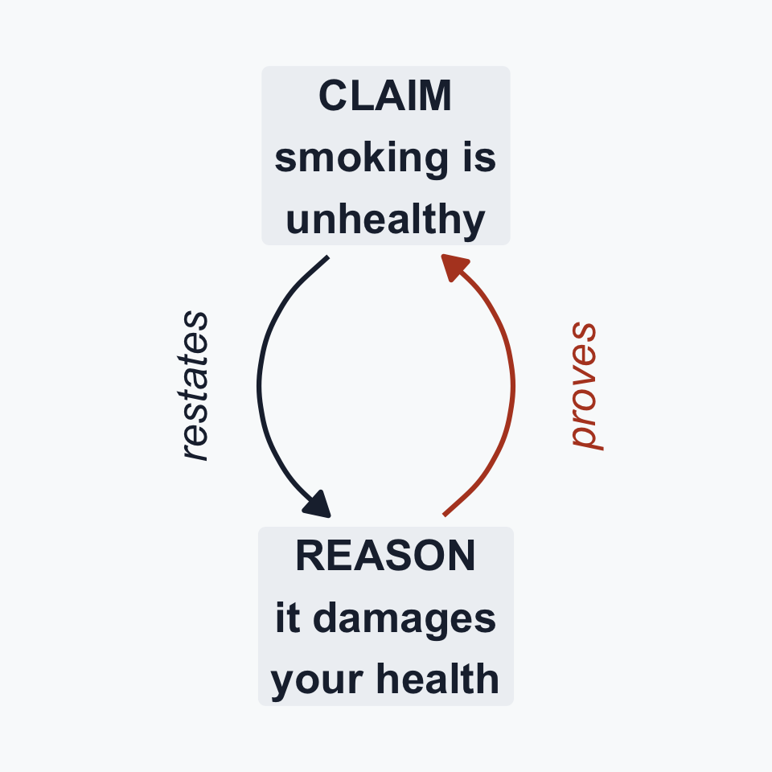

**Tautology vs. circular reasoning** — a tautology is a vacuous *statement* (“it is what it is”); circular reasoning is an *argument* whose support loops back on its conclusion. Some circles lean on a tautology — but the concepts are distinct.

## True, but Empty

> “Either it rains tomorrow, or it doesn’t.”
- **Always true** — there’s no way for it to be wrong.
- And it tells you **nothing**
- That’s a **tautology:** true because it says nothing about the world.

**Platitudes** — the everyday versions:

- “Boys will be boys.”
- “A rule is a rule.”

## Ad Hominem

> “The mayor’s numbers show the curfew cut crime; The guy’s a crook. Ignore it.”
- Only the arguer is hit
  - the numbers go unanswered.
- Even if *“he’s a crook”* is true, it doesn’t make the numbers wrong.

## “This Is Abuse” — Named at Last

[video not shown]

The room the sketch files as *abuse* has our name too: **attack the person, and the argument never happens.**

## Different Rooms

|  | Barnard’s room | “Ignore the mayor’s numbers” |
| --- | --- | --- |
| **Attacks the person?** | Yes — “you vacuous, toffee-nosed pervert” | Yes — his motives |
| **Is there an argument?** | No — none was ever offered | Yes — the crime numbers |
| **The move** | Pure **abuse** | **Ad hominem** — the attack *dismisses* the argument |

- The clinic files abuse and argument in **separate rooms**.
- The fallacy begins when the attack **replaces the answer** to a real argument.

**Test:** was there an argument — and did attacking the person make it *disappear*?

## Labels, Not Answers

> “We should restrict migration.” — “That’s racist!”  
> “We should expand welfare.” — “That’s communism!”
- The label replaces the answer.
- “Woke!” · “Fascist!” · “Denier!” · “Fake news!”
- The label might even fit — the argument still goes unanswered.
- The sign: the conversation ends once the label is applied.

## When It’s Fair

[output not shown]

Rule: questioning a source can reduce the weight of testimony

It does not, by itself, show the conclusion false.

To answer the conclusion:

- engage the reasons
- the evidence
- inferential link.

## Appeal to Authority

> “The police chief says the curfew works. **Case closed.**”
- The fallacy: status substitutes for evidence
- Another example: a Nobel physicist pronouncing on medicine (wrong field)
- **Legitimate**: citing expert consensus, in its field, with the evidence available.
- Watch for vague appeals to authority: “studies show,” “experts agree”
  - *which* studies?
  - *which* experts?

## “What Cigarette Do You Smoke, Doctor?” (1949)

[video not shown]

A real ad, run for a decade. **What is the doctor’s coat actually doing in this argument?**

## The Lab Coat

|  | What the ad shows | What it proves |
| --- | --- | --- |
| **The authority** | Doctors — “all branches of medicine” | Right field for *health* claims… |
| **The claim tested** | Which brand doctors *smoke* | …but no health claim is ever made |
| **The survey** | “Repeated, nationwide” — real | Doctors got **free cartons of Camels**, then were asked their brand |

- The doctor’s coat adds trust; the ad never gives evidence.
- A real survey can still measure nothing that matters.
- The unstated conclusion (*safe to smoke*) wasn’t tested.
- **Test:** is the authority giving evidence?

## Exercise — Name the Move

In pairs. Which of today’s four moves — if any?

1. “I started taking vitamin C in March. I haven’t been sick since. It works.”
2. “Ignore his economics argument — he has been divorced twice.”
3. “This app is the best, because no other app is as good.”
4. “A famous actor says this diet cures allergies. Good enough for me.”
5. “Crime rose the year the new mayor took office. He caused it.”
6. “The engineer inspected the bridge, found deep cracks, and says don’t cross.”

## Answers

| # | The claim | The move |
| --- | --- | --- |
| **1** | vitamin C in March, no illness since | **false cause** |
| **2** | ignore his economics — divorced twice | **ad hominem** |
| **3** | the best, because none is as good | **circular reasoning** |
| **4** | a famous actor on allergies | **appeal to authority** |
| **5** | crime rose, so the mayor caused it | **false cause** |
| **6** | the engineer found cracks — don’t cross | **no fallacy** |

- **1 and 5 are the same move** — once to praise, once to blame.
- **6 is legitimate**: right field, evidence you could go and check.

## Conclusion

Name the move, quote the words, say what would decide it.

- **Faulty reasoning**
  - false cause (after ≠ because)
  - circular reasoning (no independent support — the loop returns to the claim)
    - often via tautologies and platitudes: true because they say nothing; they prove nothing.
- **Misused sources**
  - ad hominem
  - appeal to authority